# Introduction to Classification

```python
import pandas as pd
import numpy as np
```

## Classifying Tropical Storms

The “storms” data set contains data on tropical storms since 1975. Suppose we want to use this data to train a classification model that predicts whether or not a storm is a hurricane based on its wind speed and pressure.

```python
df_storms = pd.read_csv("https://raw.githubusercontent.com/kevindavisross/data301/main/data/storms.csv")
df_storms["hurricane"] = (df_storms["status"] == "hurricane")
df_storms
```

|  | name | year | month | day | hour | lat | long | status | category | wind | pressure | tropicalstorm_force_diameter | hurricane_force_diameter | hurricane |
| --- | --- | --- | --- | --- | --- | --- | --- | --- | --- | --- | --- | --- | --- | --- |
| 0 | Amy | 1975 | 6 | 27 | 0 | 27.5 | -79.0 | tropical depression | NaN | 25 | 1013 | NaN | NaN | False |
| 1 | Amy | 1975 | 6 | 27 | 6 | 28.5 | -79.0 | tropical depression | NaN | 25 | 1013 | NaN | NaN | False |
| 2 | Amy | 1975 | 6 | 27 | 12 | 29.5 | -79.0 | tropical depression | NaN | 25 | 1013 | NaN | NaN | False |
| 3 | Amy | 1975 | 6 | 27 | 18 | 30.5 | -79.0 | tropical depression | NaN | 25 | 1013 | NaN | NaN | False |
| 4 | Amy | 1975 | 6 | 28 | 0 | 31.5 | -78.8 | tropical depression | NaN | 25 | 1012 | NaN | NaN | False |
| ... | ... | ... | ... | ... | ... | ... | ... | ... | ... | ... | ... | ... | ... | ... |
| 19061 | Wanda | 2021 | 11 | 7 | 0 | 37.4 | -37.4 | tropical storm | NaN | 35 | 1003 | 60.0 | 0.0 | False |
| 19062 | Wanda | 2021 | 11 | 7 | 6 | 38.1 | -36.4 | tropical storm | NaN | 35 | 1004 | 60.0 | 0.0 | False |
| 19063 | Wanda | 2021 | 11 | 7 | 12 | 39.2 | -34.9 | other low | NaN | 35 | 1006 | 90.0 | 0.0 | False |
| 19064 | Wanda | 2021 | 11 | 7 | 18 | 40.9 | -32.8 | other low | NaN | 40 | 1006 | 90.0 | 0.0 | False |
| 19065 | Wanda | 2021 | 11 | 8 | 0 | 43.2 | -29.7 | other low | NaN | 40 | 1006 | 70.0 | 0.0 | False |

19066 rows × 14 columns

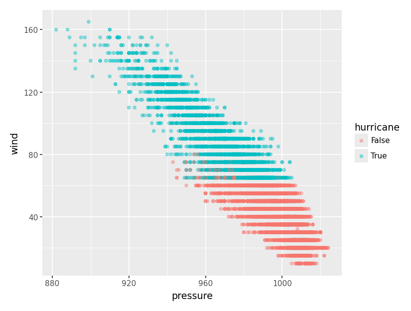

```python
from plotnine import *

(
    ggplot(
        df_storms,
        aes(x="pressure", y="wind", color="hurricane")
    )
    + geom_point(alpha=0.4)
)
```

1. Inspect the scatterplot above. Suggest a simple classification rule that you suspect will have both high precision and high recall for the hurriance class based on the training data. **Without doing any coding, specify your rule and explain your reasoning.** This is NOT asking you to do nearest neighbors. Rather suggest a simple classification rule based on what you see in the plot.

2. For each of the following **compute the value and write a clearly worded sentence interpreting the value as a percentage in context.** Again, this is NOT asking you to fit a nearest neighbors model. You can write code, but you should only need to write basic code to make your predictions and get relevant counts from the training data. You can compute things like fractions by hand.
1. training accuracy
2. training precision for the hurricane class
3. training recall for the hurricane class
4. training F1 score for the hurricane class
5. training precision for the non-hurricane class
6. training precision for the non-hurricane class
7. training F1 score for the non-hurricane class

```python
# ENTER YOUR CODE HERE
from sklearn.metrics import confusion_matrix, accuracy_score, precision_score, recall_score, f1_score

actual = df_storms["hurricane"]
predicted = df_storms["wind"] >= 64

cm = confusion_matrix(actual, predicted, labels=[True, False])
TP, FN, FP, TN = cm.ravel()
n = len(actual)
print(pd.DataFrame(cm, index=["actual hurricane", "actual non-hurricane"], columns=["predicted hurriance", "predicted non-hurricane"]))
print(f"TP = {TP}  FP = {FP}  FN = {FN}  TN = {TN}   (n = {TP + FP + FN + TN})")
```

```
                      predicted hurriance  predicted non-hurricane
actual hurricane                     4684                        0
actual non-hurricane                  128                    14254
TP = 4684  FP = 128  FN = 0  TN = 14254   (n = 19066)
```

```python
scores = pd.DataFrame({
    "formula": ["(TP + TN) / n", "TP / (TP + FP)", "TP / (TP + FN)", "2TP / (2TP + FP + FN)",
                "TN / (TN + FN)", "TN / (TN + FP)", "2TN / (2TN + FN + FP)"],
   "scikit-learn": [accuracy_score(actual, predicted),
                     precision_score(actual, predicted), recall_score(actual, predicted), f1_score(actual, predicted),
                     precision_score(actual, predicted, pos_label=False), recall_score(actual, predicted, pos_label=False),
                     f1_score(actual, predicted, pos_label=False)],
}, index=["a. accuracy", "b. precision (hurricane)", "c. recall (hurricane)", "d. F1 (hurricane)",
          "e. precision (non-hurricane)", "f. recall (non-hurricane)", "g. F1 (non-hurricane)"])
scores.round(4)
```

|  | formula | scikit-learn |
| --- | --- | --- |
| a. accuracy | (TP + TN) / n | 0.9933 |
| b. precision (hurricane) | TP / (TP + FP) | 0.9734 |
| c. recall (hurricane) | TP / (TP + FN) | 1.0000 |
| d. F1 (hurricane) | 2TP / (2TP + FP + FN) | 0.9865 |
| e. precision (non-hurricane) | TN / (TN + FN) | 1.0000 |
| f. recall (non-hurricane) | TN / (TN + FP) | 0.9911 |
| g. F1 (non-hurricane) | 2TN / (2TN + FN + FP) | 0.9955 |

3. The “status” variable contains further breakdown of the non-hurricane class. Suppose we fit a **10-nearest neighbors** classification model for predicting status from wind speed and pressure. Without doing any coding, what status would the model predict for a storm with a pressure of 975 and wind speed of 39? **Explain your reasoning without doing any coding**. Hint: look at the scatterplot below, but be careful since some points are superimposed.

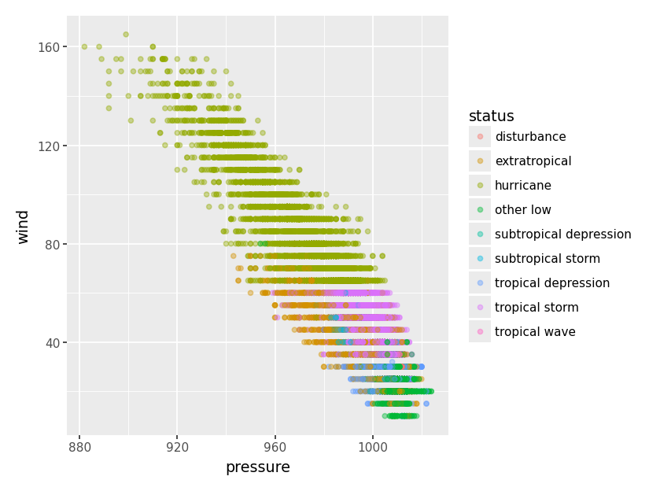

```python
(
    ggplot(
        df_storms,
        aes(x="pressure", y="wind", color="status")
    )
    + geom_point(alpha=0.4)
)
```

**DISCUSS WITH YOUR PARTNER.** The model would probably predict extratropical. A storm with low pressure but wind around 39 knots is closer to the extratropical points than to the main groups of tropical storms.

4. Suppose we fit a **10-nearest neighbors** classification model for predicting status from wind speed and pressure. Without doing any coding, which classes do you think would have the lowest recall based on the training data? **Explain your reasoning without doing any coding.** Hint: look at the scatterplot above, but be careful since some points are superimposed.

**DISCUSS WITH YOUR PARTNER.** I think the rare categories would have the lowest recall like tropical wave, disturbance, and subtropical categories. Their points overlap with more commmon types.

## Practice Activity Titanic Data

We’ll use $k$-nearest neighbors to predict who survives based on age, sex, and class.

```python
df_titanic = pd.read_csv("https://dlsun.github.io/pods/data/titanic.csv ")

# drop the NaN for age since we're using it as a predictor
df_titanic = df_titanic.dropna(subset = ["age"])

df_titanic
```

|  | name | gender | age | class | embarked | country | ticketno | fare | survived |
| --- | --- | --- | --- | --- | --- | --- | --- | --- | --- |
| 0 | Abbing, Mr. Anthony | male | 42.0 | 3rd | S | United States | 5547.0 | 7.11 | 0 |
| 1 | Abbott, Mr. Eugene Joseph | male | 13.0 | 3rd | S | United States | 2673.0 | 20.05 | 0 |
| 2 | Abbott, Mr. Rossmore Edward | male | 16.0 | 3rd | S | United States | 2673.0 | 20.05 | 0 |
| 3 | Abbott, Mrs. Rhoda Mary 'Rosa' | female | 39.0 | 3rd | S | England | 2673.0 | 20.05 | 1 |
| 4 | Abelseth, Miss. Karen Marie | female | 16.0 | 3rd | S | Norway | 348125.0 | 7.13 | 1 |
| ... | ... | ... | ... | ... | ... | ... | ... | ... | ... |
| 2202 | Wynn, Mr. Walter | male | 41.0 | deck crew | B | England | NaN | NaN | 1 |
| 2203 | Yearsley, Mr. Harry | male | 40.0 | victualling crew | S | England | NaN | NaN | 1 |
| 2204 | Young, Mr. Francis James | male | 32.0 | engineering crew | S | England | NaN | NaN | 0 |
| 2205 | Zanetti, Sig. Minio | male | 20.0 | restaurant staff | S | England | NaN | NaN | 0 |
| 2206 | Zarracchi, Sig. L. | male | 26.0 | restaurant staff | S | England | NaN | NaN | 0 |

2205 rows × 9 columns

1. Train a 10-nearest neighbors model to predict whether or not a passenger on the Titanic survived, using their age, sex, and class as features.

```python
# YOUR CODE HERE. ADD CELLS AS NEEDED
from sklearn.compose import ColumnTransformer
from sklearn.preprocessing import OneHotEncoder, StandardScaler
from sklearn.pipeline import Pipeline
from sklearn.neighbors import KNeighborsClassifier

features = ["age", "gender", "class"]
X_titanic = df_titanic[features]
y_titanic = df_titanic["survived"]
print(df_titanic["class"].value_counts().to_dict())

preprocessing = ColumnTransformer([
    ("scale", StandardScaler(), ["age"]),
    ("dummify", OneHotEncoder(), ["gender", "class"]),
])

knn_titanic = Pipeline([("preprocessing", preprocessing),
            ("knn", KNeighborsClassifier(n_neighbors=10))])
knn_titanic.fit(X_titanic, y_titanic)
print("classes_:", knn_titanic["knn"]. classes_,
"survivors in the data:", y_titanic.sum(), "of", len(y_titanic))
```

```
{'3rd': 707, 'victualling crew': 431, '1st': 324, 'engineering crew': 324, '2nd': 284, 'restaurant staff': 69, 'deck crew': 66}
classes_: [0 1] survivors in the data: 711 of 2205
```

2. Use your model to predict whether a 20-year old female in first-class would survive. What about a 20-year old female in third-class? What are the predicted probabilities for each?

```python
# YOUR CODE HERE. ADD CELLS AS NEEDED

new_people = pd.DataFrame({"age": [20, 20], "gender": ["female", "female"], "class": ["1st", "3rd"]})
new_people["predicted"] = knn_titanic.predict(new_people)
new_people["P(survived)"] = knn_titanic.predict_proba(new_people)[:, 1]
new_people
```

|  | age | gender | class | predicted | P(survived) |
| --- | --- | --- | --- | --- | --- |
| 0 | 20 | female | 1st | 1 | 1.0 |
| 1 | 20 | female | 3rd | 0 | 0.2 |

3. Calculate and interpret the training precision, recall, and F1 score for predicting survivors.

```python
# YOUR CODE HERE. ADD CELLS AS NEEDED
from sklearn.metrics import confusion_matrix, precision_score, recall_score, f1_score, accuracy_score

pred_titanic = knn_titanic.predict(X_titanic)
prob_survive = knn_titanic.predict_proba(X_titanic)[:, 1]

cm_t = confusion_matrix(y_titanic, pred_titanic)         # rows actual 0, 1; columns predicted 0, 1
TN, FP, FN, TP = cm_t.ravel()
print(pd.DataFrame(cm_t, index=["actual died", "actual survived"], columns=["predicted died", "predicted survived"]))
print(f"\nsurvivors as positive:  TP = {TP}  FP = {FP}  FN = {FN}  TN = {TN}")
print(f"precision = {TP}/({TP}+{FP}) = {TP/(TP+FP):.4f}   sklearn {precision_score(y_titanic, pred_titanic):.4f}")
print(f"recall    = {TP}/({TP}+{FN}) = {TP/(TP+FN):.4f}   sklearn {recall_score(y_titanic, pred_titanic):.4f}")
print(f"F1        = 2*{TP}/(2*{TP}+{FP}+{FN}) = {2*TP/(2*TP+FP+FN):.4f}   sklearn {f1_score(y_titanic, pred_titanic):.4f}")
print(f"(accuracy {accuracy_score(y_titanic, pred_titanic):.4f}; baseline 'everyone dies' {1 - y_titanic.mean():.4f})")
```

```
                 predicted died  predicted survived
actual died                1423                  71
actual survived             324                 387

survivors as positive:  TP = 387  FP = 71  FN = 324  TN = 1423
precision = 387/(387+71) = 0.8450   sklearn 0.8450
recall    = 387/(387+324) = 0.5443   sklearn 0.5443
F1        = 2*387/(2*387+71+324) = 0.6621   sklearn 0.6621
(accuracy 0.8209; baseline 'everyone dies' 0.6776)
```

4. Calculate and interpret the training precision, recall, and F1 score for predicting non-survivors.

```python
# YOUR CODE HERE. ADD CELLS AS NEEDED
print(f"precision (non-survivors) = TN/(TN+FN) = {TN}/({TN}+{FN}) = {TN/(TN+FN):.4f}   sklearn {precision_score(y_titanic, pred_titanic, pos_label=0):.4f}")
print(f"recall    (non-survivors) = TN/(TN+FP) = {TN}/({TN}+{FP}) = {TN/(TN+FP):.4f}   sklearn {recall_score(y_titanic, pred_titanic, pos_label=0):.4f}")
print(f"F1        (non-survivors) = 2TN/(2TN+FN+FP) = {2*TN/(2*TN+FN+FP):.4f}   sklearn {f1_score(y_titanic, pred_titanic, pos_label=0):.4f}")
```

```
precision (non-survivors) = TN/(TN+FN) = 1423/(1423+324) = 0.8145   sklearn 0.8145
recall    (non-survivors) = TN/(TN+FP) = 1423/(1423+71) = 0.9525   sklearn 0.9525
F1        (non-survivors) = 2TN/(2TN+FN+FP) = 0.8781   sklearn 0.8781
```

```python
# YOUR CODE HERE. ADD CELLS AS NEEDED
def scores_at(threshold):
    pred_t = (prob_survive >= threshold).astype(int)
    return {"threshold": threshold,
            "predicted survivors": pred_t.sum(),
            "precision (survivors)": precision_score(y_titanic, pred_t),
            "recall (survivors)": recall_score(y_titanic, pred_t),
            "precision (non-survivors)": precision_score(y_titanic, pred_t, pos_label=0),
            "recall (non-survivors)": recall_score(y_titanic, pred_t, pos_label=0)}

pd.DataFrame([scores_at(0.5), scores_at(0.8)]).set_index("threshold").round(3)
```

| threshold | predicted survivors | precision (survivors) | recall (survivors) | precision (non-survivors) | recall (non-survivors) |
| --- | --- | --- | --- | --- | --- |
| 0.5 | 575 | 0.770 | 0.623 | 0.836 | 0.912 |
| 0.8 | 329 | 0.918 | 0.425 | 0.782 | 0.982 |

```python
print("people with P(survived) exactly 0.5:", (prob_survive == 0.5).sum(),
      "-> predict() calls them non-survivors; the rule 'prob >= 0.5' calls them survivors")
```

```
people with P(survived) exactly 0.5: 117 -> predict() calls them non-survivors; the rule 'prob >= 0.5' calls them survivors
```

6. Plot the precision-recall curve for the survivors. Interpret what you see.

|  | threshold | precision | recall |
| --- | --- | --- | --- |
| 0 | 0.0 | 0.322 | 1.000 |
| 1 | 0.1 | 0.395 | 0.993 |
| 2 | 0.2 | 0.485 | 0.916 |
| 3 | 0.3 | 0.566 | 0.821 |
| 4 | 0.4 | 0.711 | 0.678 |
| 5 | 0.5 | 0.770 | 0.623 |
| 6 | 0.6 | 0.845 | 0.544 |
| 7 | 0.7 | 0.893 | 0.468 |
| 8 | 0.8 | 0.918 | 0.425 |
| 9 | 0.9 | 0.952 | 0.338 |
| 10 | 1.0 | 1.000 | 0.200 |
| 11 | NaN | 1.000 | 0.000 |

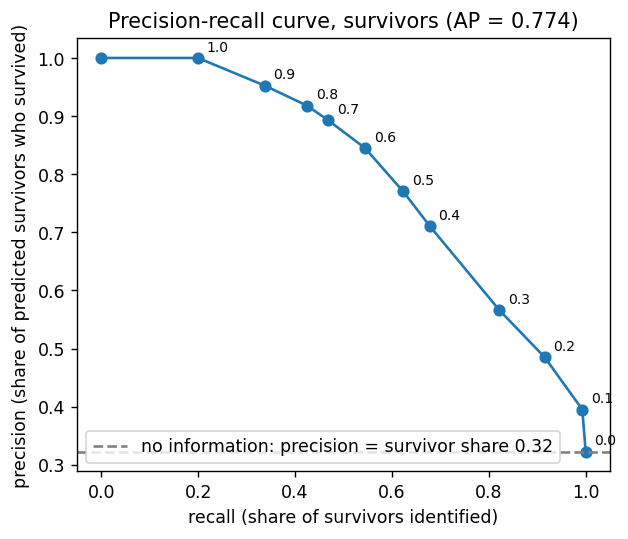

```python
# YOUR CODE HERE. ADD CELLS AS NEEDED
import matplotlib.pyplot as plt
from sklearn.metrics import precision_recall_curve, average_precision_score

prec, rec, thresholds = precision_recall_curve(y_titanic, prob_survive)
curve = pd.DataFrame({"threshold": np.append(thresholds, np.nan), "precision": prec, "recall": rec}).round(3)

fig, ax = plt.subplots(figsize=(5.5, 4.5))
ax.plot(rec, prec, marker="o")
for t_, p_, r_ in zip(thresholds, prec, rec):
    ax.annotate(f"{t_:.1f}", (r_, p_), textcoords="offset points", xytext=(5, 4), fontsize=8)
ax.axhline(y_titanic.mean(), color="grey", linestyle="--", label=f"no information: precision = survivor share {y_titanic.mean():.2f}")
ax.set_xlabel("recall (share of survivors identified)"); ax.set_ylabel("precision (share of predicted survivors who survived)")
ax.set_title(f"Precision-recall curve, survivors (AP = {average_precision_score(y_titanic, prob_survive):.3f})"); ax.legend(loc="lower left")
curve
```

7. Plot the precision-recall curve for non-survivors. Interpret what you see.

|  | threshold on P(died) | precision | recall |
| --- | --- | --- | --- |
| 0 | 0.0 | 0.678 | 1.000 |
| 1 | 0.1 | 0.724 | 1.000 |
| 2 | 0.2 | 0.759 | 0.992 |
| 3 | 0.3 | 0.782 | 0.982 |
| 4 | 0.4 | 0.794 | 0.973 |
| 5 | 0.5 | 0.815 | 0.952 |
| 6 | 0.6 | 0.836 | 0.912 |
| 7 | 0.7 | 0.850 | 0.869 |
| 8 | 0.8 | 0.892 | 0.701 |
| 9 | 0.9 | 0.930 | 0.537 |
| 10 | 1.0 | 0.988 | 0.276 |
| 11 | NaN | 1.000 | 0.000 |

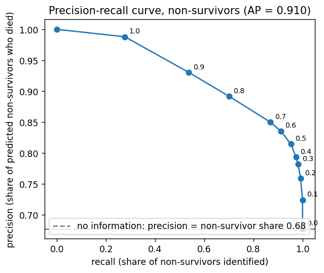

```python
# YOUR CODE HERE. ADD CELLS AS NEEDED
prob_die = 1 - prob_survive
prec0, rec0, thresholds0 = precision_recall_curve(1 - y_titanic, prob_die)
curve0 = pd.DataFrame({"threshold on P(died)": np.append(thresholds0, np.nan), "precision": prec0, "recall": rec0}).round(3)

fig, ax = plt.subplots(figsize=(5.5, 4.5))
ax.plot(rec0, prec0, marker="o")
for t_, p_, r_ in zip(thresholds0, prec0, rec0):
    ax.annotate(f"{t_:.1f}", (r_, p_), textcoords="offset points", xytext=(5, 4), fontsize=8)
ax.axhline(1 - y_titanic.mean(), color="grey", linestyle="--", label=f"no information: precision = non-survivor share {1 - y_titanic.mean():.2f}")
ax.set_xlabel("recall (share of non-survivors identified)"); ax.set_ylabel("precision (share of predicted non-survivors who died)")
ax.set_title(f"Precision-recall curve, non-survivors (AP = {average_precision_score(1 - y_titanic, prob_die):.3f})"); ax.legend(loc="lower left")
curve0
```